# Proyecto Final graficando los casos de Covid19 en R

Clemente Elizalde Marcos Alejandro, Alejo Hernandez Meztli

9/1/2021

Por medio de este trabajo queremos dar a conocer información relevante sobre los casos de Covid19 en la Ciudad de México, en este caso sobre los casos estimados, defunciones y recuperados, también como parte de este trabajo deseamos aportar las herramientas necesarias para que alumnos y otros usuarios puedan incorporar los datos para crear sus propias graficas en el programa R.

Primero empezamos agregando nuestras librerías

```r
library(ggplot2)
```

Creamos una matriz 13x4 con los datos respectivos de las semanas

```r
Semanas<-c(10,11,12,13,14,15,20,25,30,35,40,45,50)
CasosEstimados<-c(150,743,1628,3171,5590,8051,25608,46411,52990,40074,35703,48994,66525)
Defunciones<-c(1,1,4,38,156,382,2818,4439,4975,3327,2263,2922,3460)
Recuperados<-c(3,10,54,366,650,976,7792,23261,36150,30240,25153,35924,46028)
TablaCov<-cbind(Semanas,CasosEstimados,Defunciones,Recuperados)
TablaCov
```

```
##       Semanas CasosEstimados Defunciones Recuperados
##  [1,]      10            150           1           3
##  [2,]      11            743           1          10
##  [3,]      12           1628           4          54
##  [4,]      13           3171          38         366
##  [5,]      14           5590         156         650
##  [6,]      15           8051         382         976
##  [7,]      20          25608        2818        7792
##  [8,]      25          46411        4439       23261
##  [9,]      30          52990        4975       36150
## [10,]      35          40074        3327       30240
## [11,]      40          35703        2263       25153
## [12,]      45          48994        2922       35924
## [13,]      50          66525        3460       46028
```

Cambiamos el nombre de las columnas con el comando colnames y cambiamos el nombre de las filas con el comando rownames

```r
colnames(TablaCov)<-c("Semana","CasoConfirmados","Defunciones","Recuperados")
rownames(TablaCov)<-c("Semana10","Semana11","Semana12","Semana13","Semana14","Semana15","Semana20","Semana25","Semana30","Semana35","Semana40","Semana45","Semana50")
TablaCov
```

```
##          Semana CasoConfirmados Defunciones Recuperados
## Semana10     10             150           1           3
## Semana11     11             743           1          10
## Semana12     12            1628           4          54
## Semana13     13            3171          38         366
## Semana14     14            5590         156         650
## Semana15     15            8051         382         976
## Semana20     20           25608        2818        7792
## Semana25     25           46411        4439       23261
## Semana30     30           52990        4975       36150
## Semana35     35           40074        3327       30240
## Semana40     40           35703        2263       25153
## Semana45     45           48994        2922       35924
## Semana50     50           66525        3460       46028
```

Creamos un data.frame con los datos de la matriz

```r
TablaCov<-data.frame(TablaCov)
TablaCov
```

```
##          Semana CasoConfirmados Defunciones Recuperados
## Semana10     10             150           1           3
## Semana11     11             743           1          10
## Semana12     12            1628           4          54
## Semana13     13            3171          38         366
## Semana14     14            5590         156         650
## Semana15     15            8051         382         976
## Semana20     20           25608        2818        7792
## Semana25     25           46411        4439       23261
## Semana30     30           52990        4975       36150
## Semana35     35           40074        3327       30240
## Semana40     40           35703        2263       25153
## Semana45     45           48994        2922       35924
## Semana50     50           66525        3460       46028
```

Graficamos el data.frame

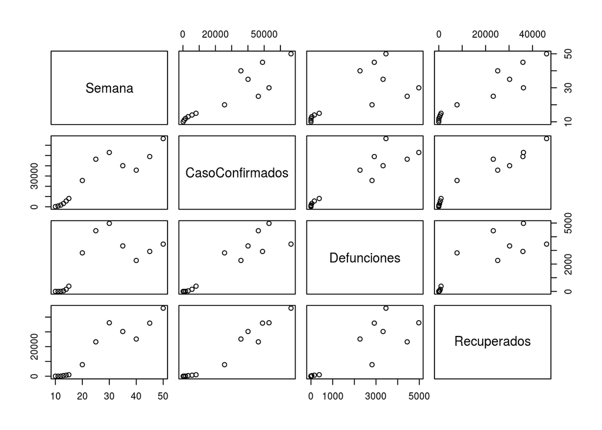

```r
plot(TablaCov)
```

Graficamos los casos estimados con el comando plot(x,y)

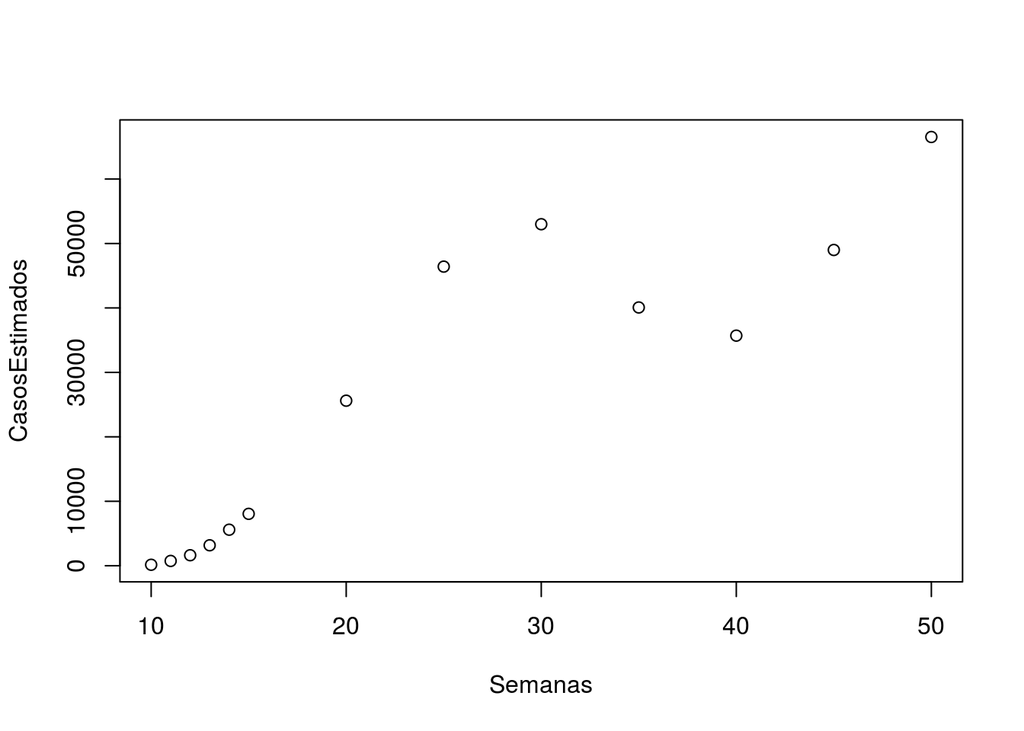

```r
plot(Semanas,CasosEstimados)
```

Estilizamos la grafica con el comando type para añadir el circulo y col para añadir el color

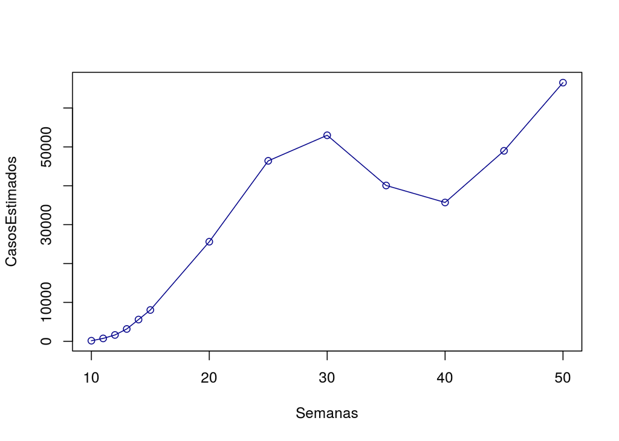

```r
plot(Semanas,CasosEstimados,type="o",col="darkblue")
```

De igual forma graficamos las defunciones solo cambiando la variable

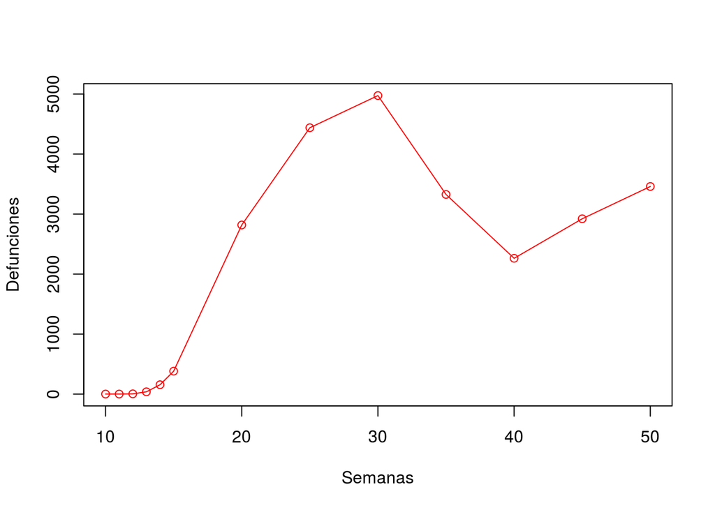

```r
plot(Semanas,Defunciones,type="o",col="red")
```

Aqui se cambia la variable a recuperados

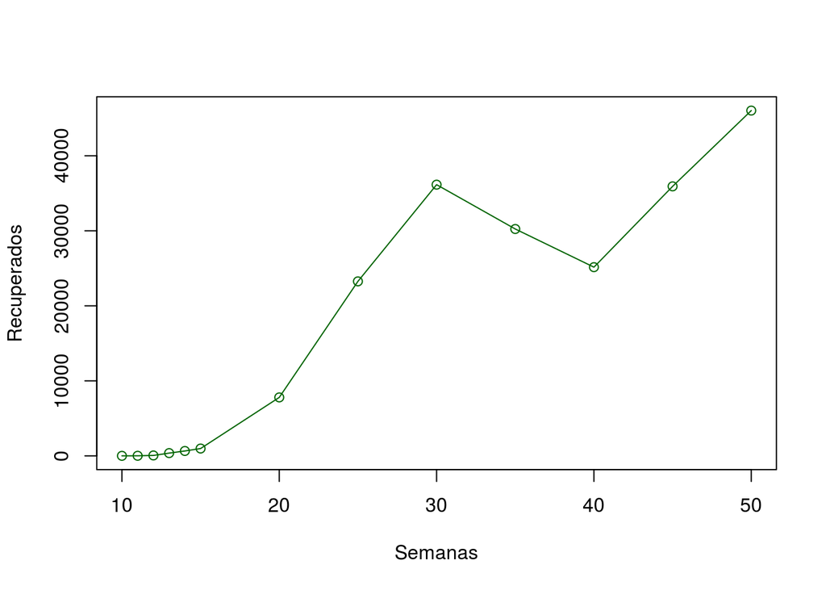

```r
plot(Semanas,Recuperados,type="o",col="darkgreen")
```

Si se busca una estética más interactiva y profesional usa el comando ggplot( data = nombre del data.frame, aes(x=Semanas,y=CasosEstimados))+geom_point para añadir un punto(size=numero del tamaño,colour=“#codigo del color”)+ geom_line para añadir una línea entre los puntos(size=numero del tamaño,colour=“#codigo del color”)+ geom_bar para crear una barra (stat=“identity” sirve para mostrar las barras ,width = numero del ancho de la barra ,colour=“#codigo del color”)

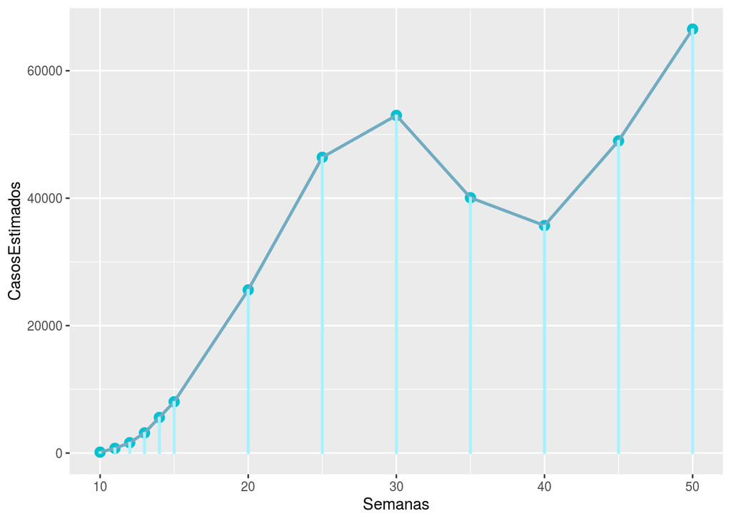

```r
ggplot(data = TablaCov, aes(x=Semanas,y=CasosEstimados))+geom_point(size=3,colour="#03C1D1")+geom_line(size=1,colour="#70ACC2")+geom_bar(stat="identity",width = .1,colour="#A6F2FF")
```

Puedes usar el mismo codigo que el anterior cambiando la variable “y” para graficar las demas

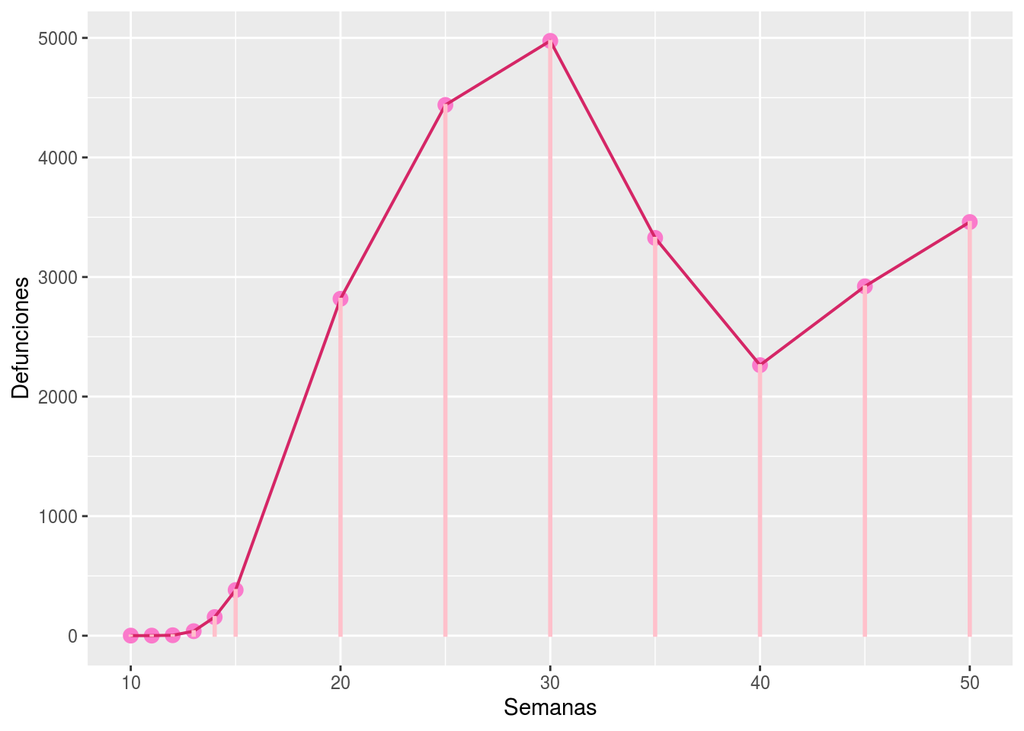

```r
ggplot(data = TablaCov, aes(x=Semanas,y=Defunciones))+geom_point(size=3,colour="#FA7ACB")+geom_line(size=.7,colour="#D52666")+geom_bar(stat="identity",width = .1,colour="pink")
```

Ademas puedes cambiar el grosor y color editando el codigo

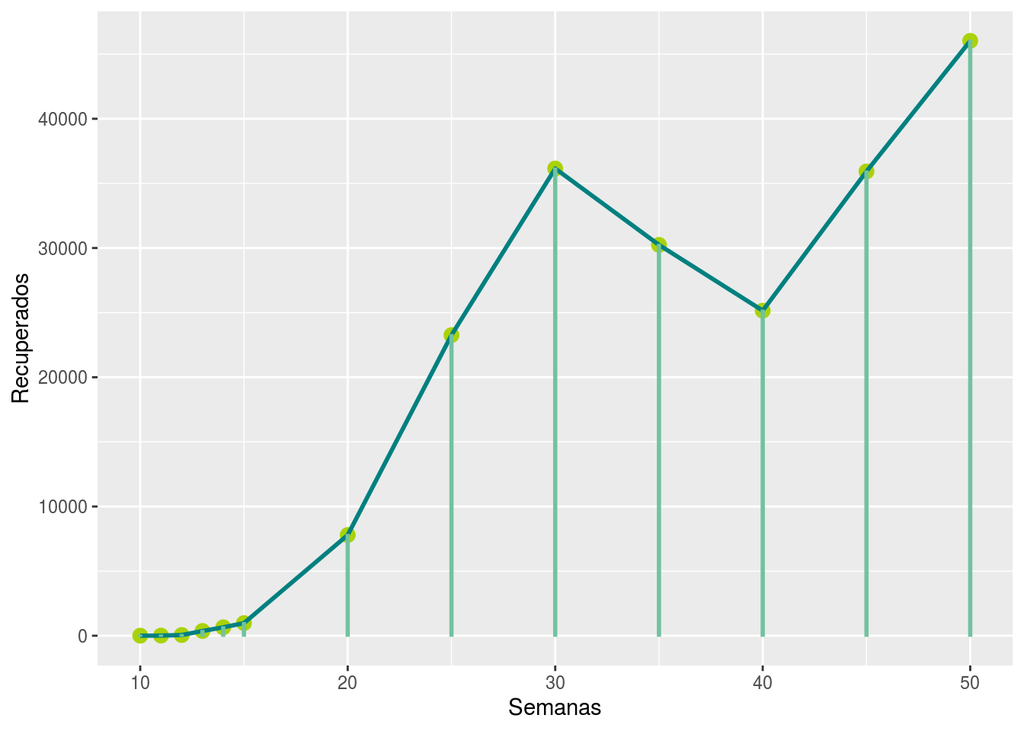

[video not shown]

```r
ggplot(data = TablaCov, aes(x=Semanas,y=Recuperados))+geom_point(size=3,colour="#AAD209")+geom_line(size=1,colour="#008080")+geom_bar(stat="identity",width = .1,colour="#72C2A0")
```